# VIS_2129_Creative_Assignment_4

Wilbert Sanchez

10/2/2020

# Assingment Commentary and Description

### In this assignment I set out to explore neighborhoods in 2 Latin America cities that I know: Sao Paulo and Mexico City. The Sao Paulo data portal had very few KML files of interest and Mexico City had what I was looking for: schools and green spaces. Hence, by elimination I chose Mexico City and a neighbouhood I was familiar with: Tlalpan.

### I ran into several issues, one of them being, the lack of neighbourhood specific data from the outset, which meant downloading the whole of Mexico City set. This was “expensive” over rural internet. It took a very long time to download in OSM and the original KML file.

### Lastly, on the technical front, I could not count the intersections; I would like to get office hours for that.

### Creating new folders to begin work and defining the paths

### Downloading the data in KLM files from Data Portals

### Setting up the planes to Mexican features

### Loading up Street Data from Open Street Map

### Setting up OTP & Isochrones

### Graphical Object #1 - Walk Shed 1km / 10minutes from schools in the Tlalpan neighbourhood (delineated in red)

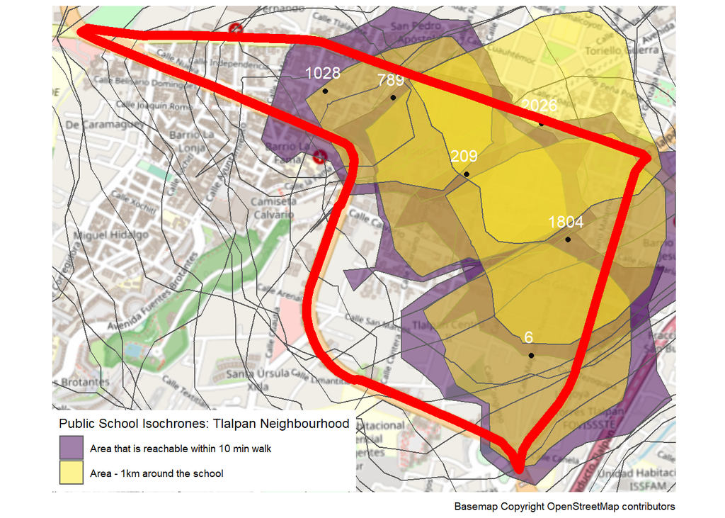

```r
#graphing
right_side <- st_bbox(n1)$xmax
left_side  <- st_bbox(n1)$xmin
top_side <- st_bbox(n1)$ymax
bottom_side <- st_bbox(n1)$ymin

#mapping, it takes a while
#(object1 <- ggplot(iso_all_modes) +
 # annotation_map_tile(zoomin = 0, progress = "none")
  #+ geom_sf(aes(fill = mode), alpha = 0.5)
  #+ geom_sf(data = CDMX_public_schools)
  #+ coord_sf(xlim = c(left_side, right_side), ylim = c(bottom_side, top_side), expand = FALSE)
  #+ scale_fill_viridis_d(name = "Area that is reachable within 5 minutes", labels = c("By car", "By foot"))
 # + theme_map()
  #+ labs(caption = "Basemap Copyright OpenStreetMap contributors"))


#n1 <- CDMX_colonias_trans["LOMAS DE CHAPULTEPEC",]
bb <- st_bbox(n1)
left_side <- st_bbox(n1)$xmin
top_side <- st_bbox(n1)$ymax

#Created a firs plot here to show the schools
#(object1a <- ggplot(iso_all_modes) +
 ## annotation_map_tile(zoomin = 0, progress = "none")
  #+ geom_sf(aes(fill = mode), alpha = 0.5)
  #+ geom_sf(data = n3)
  #+ geom_sf_text(data = n3, aes(label = id), colour = "white", size = 4, nudge_x = -10, nudge_y = +80)
  #+ coord_sf(xlim = c(left_side, right_side), ylim = c(bottom_side, top_side), expand = FALSE)
  #+ scale_fill_viridis_d(name = "Area that is reachable within 5 minutes", labels = c("By car", "By foot"))
  #+ geom_sf(data = n1, alpha = .05, colour = "red", size = 3)
  #+ theme_map()
  #+ labs(caption = "Basemap Copyright OpenStreetMap contributors")
  #+ xlim(c(bb[1],bb[3]))
  #+ ylim(c(bb[2],bb[4]))
  #)

#First Graphical Object. Looking at one neighbourhood (where I grew up in Mexico City) - Tlalpan
(object1b <- ggplot(iso_all_modes_reduced) +
  annotation_map_tile(zoomin = 0, progress = "none")
  + geom_sf(aes(fill = mode), alpha = 0.5)
  + geom_sf(data = n3)
  + geom_sf_text(data = n3, aes(label = id), colour = "white", size = 4, nudge_x = -10, nudge_y = +80)
  + coord_sf(xlim = c(left_side, right_side), ylim = c(bottom_side, top_side), expand = FALSE)
  + scale_fill_viridis_d(name = "Public School Isochrones: Tlalpan Neighbourhood", labels = c("Area that is reachable within 10 min walk", "Area - 1km around the school"))
  + geom_sf(data = n1, alpha = .05, colour = "red", size = 3)
  + theme_map()
  + labs(caption = "Basemap Copyright OpenStreetMap contributors")
  + xlim(c(bb[1],bb[3]))
  + ylim(c(bb[2],bb[4]))
)
```

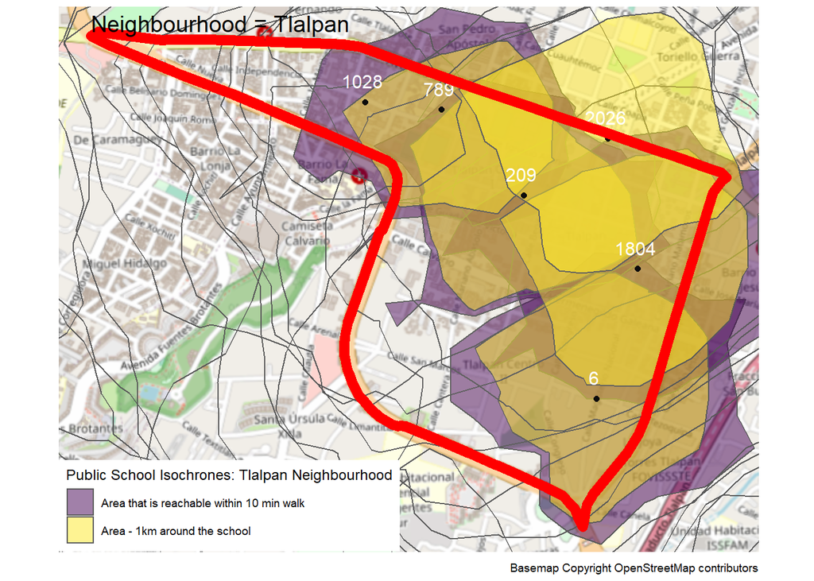

```r
(object1b
  + annotate(geom = "text", x = left_side, y = top_side, label = "Neighbourhood = Tlalpan", hjust = 0, vjust = 0, size = 5, colour = "black", alpha = 1))
```

### Creating Scatter Plot of Drive / Walk Isochrones for all of Mexico City.

```r
#calculating areas but first taking out irrelevant values
iso_areas <- iso_all_modes %>% mutate (area = st_area(iso_all_modes)) %>% st_set_geometry(NULL) %>% pivot_wider (names_from = mode, values_from = area)

iso_areas$drivenum <- NA

iso_areas <- iso_areas %>%
  filter(drive != "NULL", walk != "NULL") %>%
  filter(str_detect(drive,"c")==FALSE)

typeof(iso_areas$walk)
```

```
## [1] "list"
```

```r
iso_areas$walknum <- as.numeric(iso_areas$walk)
summary(as.numeric(iso_areas$walk))
```

```
##    Min. 1st Qu.  Median    Mean 3rd Qu.    Max.
##       0  636096  731514  704186  803977 1073627
```

```r
summary(as.numeric(iso_areas$drive))
```

```
##     Min.  1st Qu.   Median     Mean  3rd Qu.     Max.
##        0  9742794 12200320 12228357 14865431 28518600
```

[figure not shown]

```r
#creating a scatterplot of the walk and drive isochrone areas for schools in all of Mexico City
(object3 <- ggplot(iso_areas, aes(x= as.numeric(walk), y = as.numeric(drive)))
  + geom_point()
  + scale_x_continuous(name = "Area within a 10min walk of a public school\n(CDMX)", breaks = breaks <- seq(10000, 1100000, by = 100000), labels = breaks / 1000000)
  + scale_y_continuous(name = "Area within a 10min drive of a public school\n(CDMX)", breaks = breaks <- seq(0, 30000000, by = 5000000), labels = breaks / 1000000)
  + annotate("segment", x = 0, xend = 1*1000000, y = 12265313, yend = 12265313, colour = "red")
  + annotate("text", x = 1*1000000, y = 13000000, colour = "red", label = "Average Drive\nArea = 12,265mts^2")
  + annotate("segment", x = 703964, xend = 703964, y = 0, yend = 25*1000000, colour = "red")
+ annotate("text", x = 703964, y = 25*1000000, colour = "red", label = "Average Walk\nArea = 703mts^2")
  + theme_bw()
  )
```

### Creating a histogram of a newly created index => Drive/Walk multiple.

### Observation: It would be interesting as a comparison, to understand what the multiple is for other cities. My hypothesis is that Mexico City is so dense that the multiple here is lower than say a medium sized city in the US; this could be a measure of urban design.

```r
#cleaning up the data
iso_areas <- iso_areas%>% filter(walk != 0, drive != 0) %>% mutate(W_D_Index = as.numeric(drive)/ as.numeric(walk))

summary(iso_areas$W_D_Index)
```

```
##     Min.  1st Qu.   Median     Mean  3rd Qu.     Max.
##  0.00151 13.73014 16.94102 17.33334 20.39792 53.14337
```

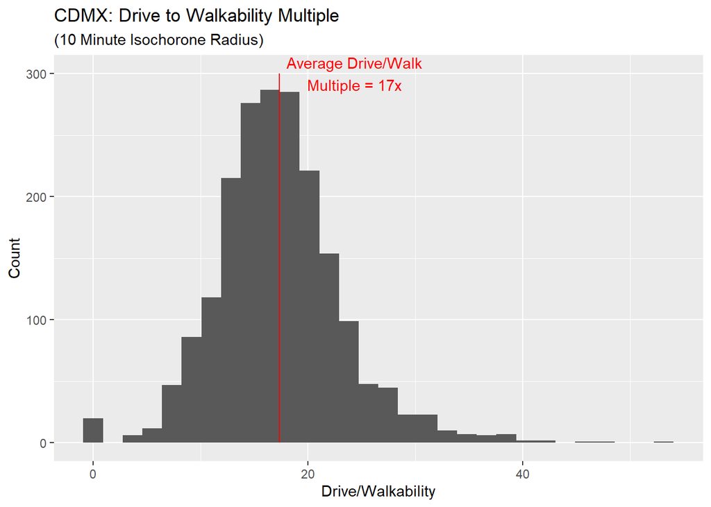

```r
(object4 <- ggplot(iso_areas, aes(W_D_Index))
  + geom_histogram()
  #+ scale_x_binned()
  +  labs(title="CDMX: Drive to Walkability Multiple", subtitle = "(10 Minute Isochorone Radius)")
  + xlab("Drive/Walkability")
  + ylab("Count")
  + annotate("segment", x = mean(iso_areas$W_D_Index), xend = mean(iso_areas$W_D_Index), y = 0, yend = 300, colour = "red")
  + annotate("text", x = mean(iso_areas$W_D_Index)+ 7, y = 300, label = paste0("Average Drive/Walk\nMultiple = ",  prettyNum(mean(iso_areas$W_D_Index), digits = 2, ), "x"), color = "red")
  )
```

```r
roads_agg <- aggregate(x = CDMX_streets2["osm_id"], by = CDMX_streets2$geometry, FUN = length)

help("aggregate")

help(osm_roads)
```

```
## No documentation for 'osm_roads' in specified packages and libraries:
## you could try '??osm_roads'
```